# DV Assignment 2, Part 1: Initial Exploration

Group 2: Filip Gawrylczyk, Teodora Costache, Andrei Dunuta

2026-10-04

## Research question

RQ 3. Do schools with similar test results give similar secondary-school advice?

*Level*: Inference

*Target audience*: secondary schools, or policymakers.

## Exploratory process

*Describe how you explored the data. Include at least one exploratory visualization below, and a short note on what it shows, and what you learned from it about your research question.*

```r
# Taking this from assignment 1 and adding VESTIGINGSCODE
# as a grouper, so we can use every school.
school_provider <- eindscores |>
  select(INSTELLINGSCODE, VESTIGINGSCODE, matches("_(AANTAL|GEM)$")) |>
  pivot_longer(
    cols = matches("_(AANTAL|GEM)$"),
    names_to = c("provider", ".value"),
    names_pattern = "(.+)_(AANTAL|GEM)"
  ) |>
  # DUO writes "<5" for small counts, so we decided to get
  # rid of it because the computations would make no sense.
  mutate(AANTAL = suppressWarnings(as.numeric(AANTAL))) |>
  filter(!is.na(AANTAL), AANTAL > 0, !is.na(GEM), GEM > 0) |>
  group_by(INSTELLINGSCODE, VESTIGINGSCODE, provider) |>
  summarise(AANTAL = sum(AANTAL), .groups = "drop")
# Same as assignment 1, adding VESTIGINGSCODE.
primary_provider <- school_provider |>
  group_by(INSTELLINGSCODE, VESTIGINGSCODE) |>
  slice_max(AANTAL, n = 1, with_ties = FALSE) |>
  ungroup() |>
  select(INSTELLINGSCODE, VESTIGINGSCODE, provider)

count_cols <- c(
  "REKENEN_LAGER1F", "REKENEN_1F", "REKENEN_1S",
  "LV_LAGER1F", "LV_1F", "LV_2F",
  "TV_LAGER1F", "TV_1F", "TV_2F"
)
# Same as assignment 1 to make the score column,
# of many people "pass" both literature and math level. Also
# added VESTIGINGSCODE again.
ref_levels <- referentieniveaus |>
  mutate(across(all_of(count_cols), ~ suppressWarnings(as.numeric(.)))) |>
  group_by(INSTELLINGSCODE, VESTIGINGSCODE) |>
  summarise(
    across(all_of(count_cols), ~ sum(.x, na.rm = TRUE)),
    .groups = "drop"
  ) |>
  mutate(
    rekenen_n = REKENEN_LAGER1F + REKENEN_1F + REKENEN_1S,
    taal_lv_n = LV_LAGER1F + LV_1F + LV_2F,
    taal_tv_n = TV_LAGER1F + TV_1F + TV_2F,
    score = (
      100 * REKENEN_1S / rekenen_n +
        100 * LV_2F / taal_lv_n +
        100 * TV_2F / taal_tv_n
    ) / 3,
    n_students = rekenen_n
  ) |>
  filter(rekenen_n > 0, taal_lv_n > 0, taal_tv_n > 0) |>
  select(INSTELLINGSCODE, VESTIGINGSCODE, score, n_students)
# Joining reference with primary provider.
school_data <- ref_levels |>
  inner_join(primary_provider, by = c("INSTELLINGSCODE", "VESTIGINGSCODE"))

# Now to the actual changes -
# joining with schooladviezen, to have school advices
# per school.
school_data <- school_data |>
  left_join(schooladviezen |>
    select(
           INSTELLINGSCODE:INSTELLINGSNAAM_VESTIGING,
           PLAATSNAAM,
           GEMEENTENAAM,
           PROVINCIE,
           VSO:ADVIES_NIET_MOGELIJK),
  by = c("INSTELLINGSCODE", "VESTIGINGSCODE"))

# Since DUO writes small numbers as <5, the options
# are for it to be 1, 2, 3 or 4, and the average is 2.5.
# BUT THEN if we use 2.5 the numbers get inflated a lot over
# n_student, for example a school with 13 student had a total
# of advices as 30 - this happened with many schools.
# Because of this we tried to use 2 instead of 2.5 -
# close to the average of possibilities but a bit lower, but
# it was still too much overshoot.
# Later on we decided to find the exact number that would
# make an average percentage count towards 100%, the computation
# is found later as part of advice_check.


school_data <- school_data |>
  mutate(across(VSO:ADVIES_NIET_MOGELIJK,
                ~ as.numeric(replace(.x, .x == "<5", "1.621641"))))

# Dropping any NAs that might be in the data and combining
# different advice types into at least VWO, at least HAVO
# (without the VWO) and all lower than those.

school_data <- school_data |>
  drop_na(score, n_students, VSO:VWO) |>
  group_by(INSTELLINGSCODE, VESTIGINGSCODE) |>
  mutate(at_least_VWO = HAVO_VWO + VWO,
         at_least_HAVO = VMBO_GT_HAVO + HAVO,
         VMBO_or_worse = rowSums(pick(VSO:VMBO_GT)))
# Now time to check what numbers are the best to replace <5 with
# so that there is no issue with schools having too many
# or too few students. When we were using 2, this was an issue.

advice_check <- school_data |>
  group_by(INSTELLINGSCODE, VESTIGINGSCODE) |>
  mutate(total_advice = at_least_VWO + at_least_HAVO + VMBO_or_worse,
         over_advice = total_advice - n_students) |>
  summarize(total_advice, n_students, over_advice, .groups = "drop_last")
# The mean with <5 being replaced by 2 was 1.8.
# Then we computed a number that would make it 0. IF all computations
# go correctly, all the following numbers will equal 0.
mean(advice_check$over_advice)
```

```
## [1] -1.160682e-08
```

```r
# This is the sum by which our replacement overshoots.
sum_over <- sum(advice_check$over_advice)

# This is how many numbers replacing <5 we have in a dataset
n_two <- school_data |>
  ungroup() |>
  select(VSO:VWO) |>
  as.matrix() |>
  (\(x) sum(x == 1.621641, na.rm = TRUE))()

# Simple division to lower the overshoot by the amount we need.
# Currently should equal the correct number, because
# the overshoot is 0

1.621641 - (sum_over / n_two)
```

```
## [1] 1.621641
```

```r
# Now we will calculate percentages of students
# in each school that got each advice.
# Later, since some schools had a lot too many or too few
# advices compared to students, we normalize the number
# into advice divided by advices given * 100 for percentage.
# At the end, filtering out one school in Utrecht that gave
# no advice at all, so along the way we divided by 0.
school_data <- school_data |>
  mutate(VWO_percent = (at_least_VWO / n_students) * 100,
         HAVO_percent = (at_least_HAVO / n_students) * 100,
         VMBO_percent = (VMBO_or_worse / n_students) * 100,
         total = VWO_percent + HAVO_percent + VMBO_percent,
         across(VWO_percent:VMBO_percent, ~ 100 * .x / total)) |>
  select(!VSO:VMBO_or_worse, -total) |>
  filter(is.finite(score) &
           is.finite(VWO_percent) &
           is.finite(HAVO_percent) &
           is.finite(VMBO_percent))

# Now we pivot the dataframe so that it is easier to put it into
# ggplot.

school_data <- school_data |>
  pivot_longer(c(VWO_percent, HAVO_percent, VMBO_percent),
               names_to = "group", names_pattern = "(.+)_percent",
               values_to = "pct") |>
  mutate(group = factor(group, levels = c("VWO", "HAVO", "VMBO")))
```

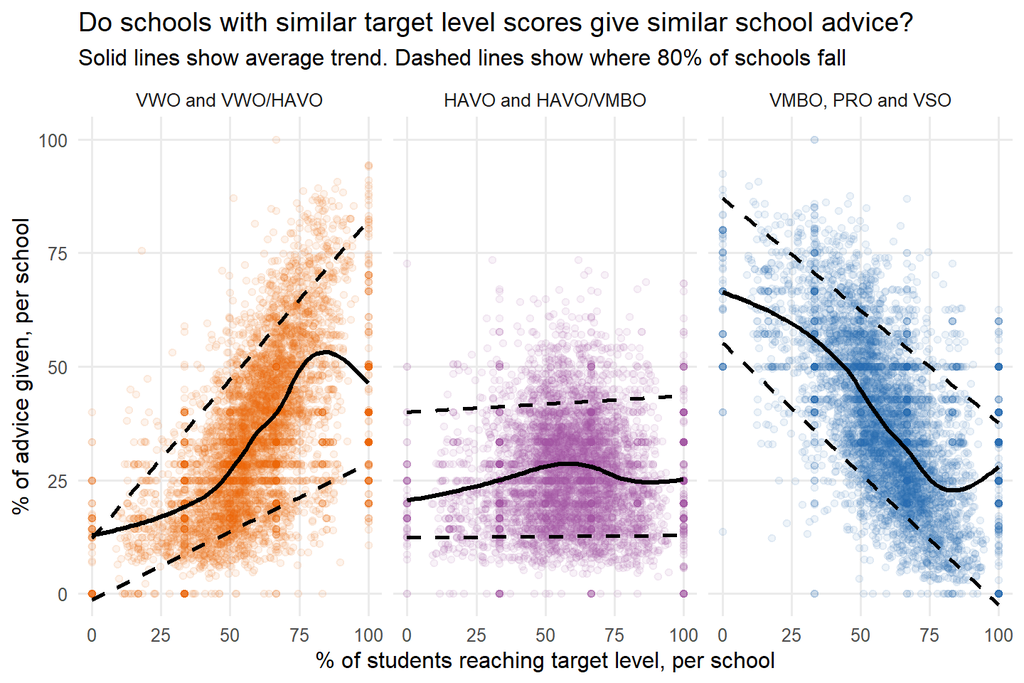

```r
# Making plot with score on x axis, and each line
# representing the percentage of students with each advice.
# Y-axis is that percentage.
ggplot(school_data, aes(x = score, y = pct)) +
  # We add points for each school on the plot to be able
  # to visualize the spread
  geom_point(aes(color = group), alpha = 0.075) +
  # And add a line in the middle, that shows where, more or less
  # the averages are.
  geom_smooth(se = FALSE, color = "black") +
  # Now with geom_quantile we create quantile lines, that
  # show us where 80% of schools fall, to be able
  # to see whether different schools give similar advice
  # if they have similar test results, the line is dashed.
  geom_quantile(quantiles = c(0.1, 0.9),
                color = "black",
                linetype = "dashed",
                linewidth = 1) +
  # In order to see all 3 plots at once we use facet wrap.
  facet_wrap(~ group, nrow = 1,
             labeller = as_labeller(c(VWO = "VWO and VWO/HAVO",
                                      HAVO = "HAVO and HAVO/VMBO",
                                      VMBO = "VMBO, PRO and VSO"))) +
  # And we add some colors that are quite different from one another
  # But still show that there are factors so VMBO -> HAVO -> VWO
  scale_color_manual(values = c(VWO = "#E66101",
                                HAVO = "#9E4F9E",
                                VMBO = "#2166AC"),
                     guide = "none") +
  # Adding normal labels.
  labs(x = "% of students reaching target level, per school",
       y = "% of advice given, per school",
       title = paste0("Do schools with similar target level ",
                      "scores give similar school advice?"),
       subtitle = paste0("Solid lines show average trend. Dashed lines ",
                         "show where 80% of schools fall")) +
  # Since the percentage chance is 0 to 100 for both axes,
  # we changed both axes to show the entire range of possibilities.
  coord_cartesian(xlim = c(0, 100), ylim = c(0, 100)) +
  # theme_minimal with larger text size and no minor grid.
  theme_minimal(base_size = 12) +
  theme(panel.grid.minor = element_blank())
```

*The above plot shows % of advice given per school based on % of students in that school that reached target level. It includes lines showing that relationship for each recommendation type (like VWO or VMBO) and also includes singular schools as points. To be able to visualize the spread, and whether it is large, we showed 80% range of schools, and around where it is. It seems that there indeed is a relationship between how many children reach target level and what type of advice is given. Based on our research question, it does seem that a lot of schools, even if they have similar test results, give very different advice, which seems to be the case for all plots but especially the higher end of the VWO range, where the advice is very different between schools. For example, there are schools with 100% having reached the target. Some schools give VWO advice around >85% of the time, while other schools give VWO advice only 15% of the time.*

```r
# In case there are multiple locations (vestings) in a school all the
# schoolweging scores in that school (instellings) are averaged. This way there
# is for sure only one score per school and it is easier to compute.

# Right now, the codes for each school/location are merged in the OVT column
# (i.e  00AP|C1, which has the intellingscode and the vestingscode). I am first
# separating them so that I can filter the schools properly, then averagnig the
# scores.

schoolweging_by_school <- schoolweging |>
  separate(OVT, into = c("INSTELLINGSCODE", "schoolweging_location"),
           sep = "\\|", remove = FALSE) |>
  mutate(
    schoolweging = as.numeric(str_replace(as.character(schoolweging),
                                          ",", ".")),
    aantal_leerlingen = as.numeric(str_replace(as.character(aantal_leerlingen),
                                               ",", "."))
  ) |>
  filter(!is.na(INSTELLINGSCODE), !is.na(schoolweging)) |>
  group_by(INSTELLINGSCODE) |>
  summarise(
    schoolweging = weighted.mean(
      schoolweging,
      w = if_else(is.na(aantal_leerlingen) | aantal_leerlingen <= 0, 1,
                  aantal_leerlingen)
    ),
    .groups = "drop"
  )

#IM saving all the averaged schoolweging scores in a separate data set so that
# I can work with it without getting in the way of anyone else working on the
# school_data variable.
school_data_schoolweging <- school_data |>
  left_join(schoolweging_by_school, by = "INSTELLINGSCODE") |>
  filter(is.finite(schoolweging), is.finite(pct))
```

```
## Smoothing formula not specified. Using: y ~ x
## Smoothing formula not specified. Using: y ~ x
## Smoothing formula not specified. Using: y ~ x
```

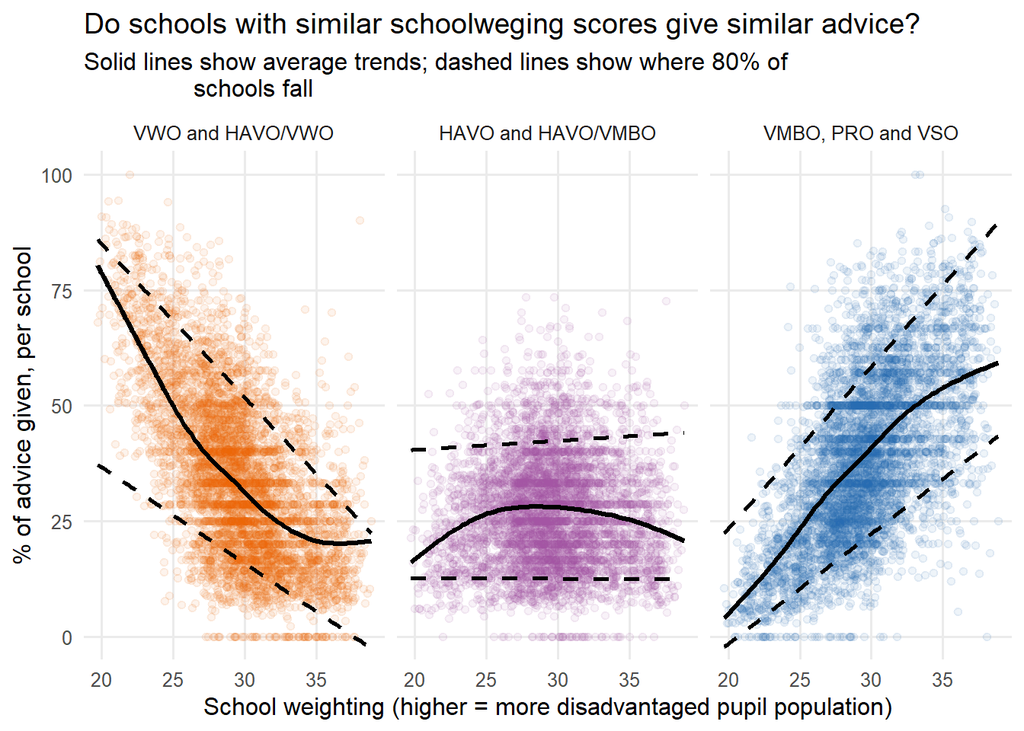

```r
# This graph looks at whether schools with a similar schoolweging score tend to
# give similar advice, and what that advice tends to be.

# The specific question I had in mind was: Do schools with a higher schooling
# score (more disadvantage) tend to recommand schools of a lower rank?

#This graph is stylistically the same as the one above, for the sake of
# consistancy. But I do want to make more, just to play around.

ggplot(school_data_schoolweging, aes(x = schoolweging, y = pct)) +
  geom_point(aes(color = group), alpha = 0.075) +
  geom_smooth(se = FALSE, color = "black") +
  geom_quantile(quantiles = c(0.1, 0.9), color = "black", linetype = "dashed",
                linewidth = 1) +
  facet_wrap(~ group, nrow = 1,
             labeller = as_labeller(c(VWO = "VWO and HAVO/VWO",
                                      HAVO = "HAVO and HAVO/VMBO",
                                      VMBO = "VMBO, PRO and VSO"))) +
  scale_color_manual(values = c(VWO = "#E66101",
                                HAVO = "#9E4F9E",
                                VMBO = "#2166AC"), guide = "none") +

  labs(
    x = "School weighting (higher = more disadvantaged pupil population)",
    y = "% of advice given, per school",
    title = "Do schools with similar schoolweging scores give similar advice?",
    subtitle = "Solid lines show average trends; dashed lines show where 80% of
                schools fall"
  ) +
  coord_cartesian(ylim = c(0, 100)) +
  theme_minimal(base_size = 12) +
  theme(panel.grid.minor = element_blank())
```

*The above plot shows % of advice given per school based on the average schoolweging score of an institution. The dashed lines represent the spread of the data (in this case, where 80% of the schools fall). The solid lines capture the trend of the data. This graph indicates that there might indeed be a realtionship between the schoolweging scores and the type of advice given. The left-most (orange) part of the graph, seems to indicate that schools with a low disadvantage weight are more likely to advice VWO and HAVO/VWO (more academic schools), for the future. ON the other side (the blue graph), suggests that schools with a high disadvantage score tend to advise VMBO, PRO or VSO more (more practical or special needs schools).*

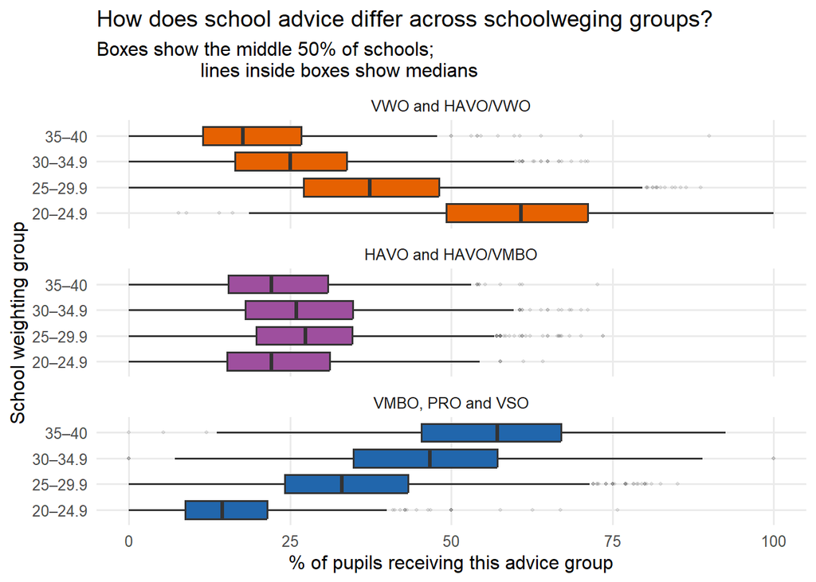

```r
# Tried to do a boxplot for the same data, because I think boxplots are cool,
# but I do think it makes more sense to look at schoolweging (a continuous var)
# on a scatterplot. The boxplot is nice tho, because you can see the means each
# subgroup a bit better.
school_data_boxplot <- school_data_schoolweging |>
  mutate(schoolweging_group = cut(schoolweging,
                                  breaks = c(20, 25, 30, 35, 40),
                                  include.lowest = TRUE,
                                  right = FALSE,
                                  labels = c("20–24.9", "25–29.9",
                                             "30–34.9", "35–40")),
         advice_group = factor(group, levels = c("VWO", "HAVO", "VMBO"),
                               labels = c("VWO and HAVO/VWO",
                                          "HAVO and HAVO/VMBO",
                                          "VMBO, PRO and VSO"))) |>
  filter(!is.na(schoolweging), !is.na(schoolweging_group), !is.na(pct))

ggplot(
  school_data_boxplot,
  aes(x = schoolweging_group, y = pct, fill = advice_group)
) +
  geom_boxplot(
    outlier.alpha = 0.12,
    outlier.size = 0.7,
    width = 0.7
  ) +
  coord_flip() +
  facet_wrap(~ advice_group, ncol = 1) +
  scale_fill_manual(values = c("VWO and HAVO/VWO" = "#E66101",
                               "HAVO and HAVO/VMBO" = "#9E4F9E",
                               "VMBO, PRO and VSO" = "#2166AC"),
                    guide = "none") +

  scale_y_continuous(limits = c(0, 100)) +
  labs(x = "School weighting group",
       y = "% of pupils receiving this advice group",
       title = "How does school advice differ across schoolweging groups?",
       subtitle = "Boxes show the middle 50% of schools;
                   lines inside boxes show medians") +
  theme_minimal(base_size = 12) +
  theme(panel.grid.minor = element_blank())
```

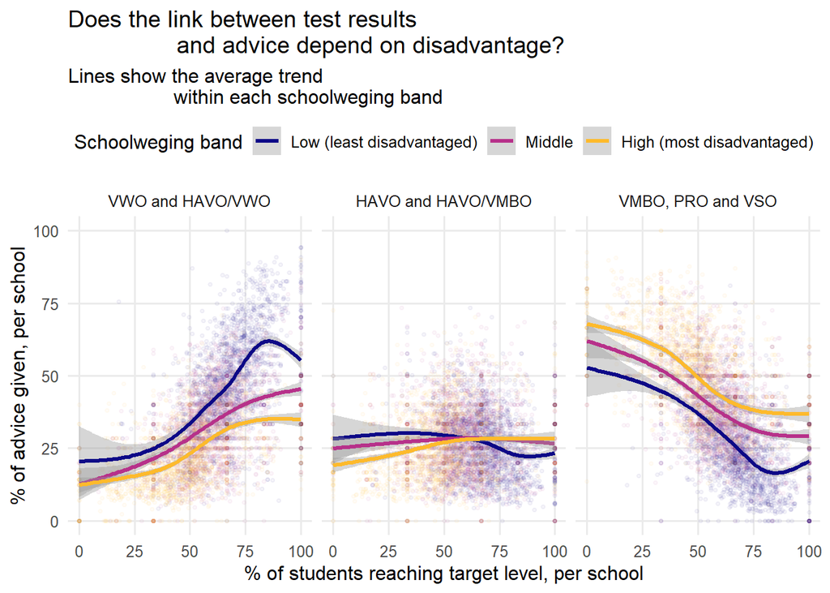

```r
# Split schools into three equal-sized schoolweging bands, so we can see
# whether the score -> advice relationship changes with disadvantage.
interaction_data <- school_data_schoolweging |>
  ungroup() |>
  mutate(
    weging_band = cut(
      schoolweging,
      breaks = quantile(schoolweging, probs = c(0, 1 / 3, 2 / 3, 1)),
      include.lowest = TRUE,
      labels = c("Low (least disadvantaged)", "Middle",
                 "High (most disadvantaged)")
    )
  )

ggplot(interaction_data, aes(x = score, y = pct, color = weging_band)) +
  geom_point(alpha = 0.04, size = 0.8) +
  geom_smooth(method = "gam", formula = y ~ s(x, bs = "cs"),
              se = TRUE, linewidth = 1.1) +
  facet_wrap(~ group, nrow = 1,
             labeller = as_labeller(c(VWO = "VWO and HAVO/VWO",
                                      HAVO = "HAVO and HAVO/VMBO",
                                      VMBO = "VMBO, PRO and VSO"))) +
  scale_color_viridis_d(option = "plasma", end = 0.85,
                        name = "Schoolweging band") +
  labs(x = "% of students reaching target level, per school",
       y = "% of advice given, per school",
       title = "Does the link between test results
                and advice depend on disadvantage?",
       subtitle = "Lines show the average trend
                   within each schoolweging band") +
  coord_cartesian(xlim = c(0, 100), ylim = c(0, 100)) +
  theme_minimal(base_size = 12) +
  theme(panel.grid.minor = element_blank(), legend.position = "top")
```

*The above plot combines our two previous graphs by showing the relationship between test results and advice separately for three equally sized groups of schools, split by their schoolweging score (low, middle and high disadvantage). If schoolweging made no difference, the three lines in each panel would lie on top of each other. If it only shifted advice up or down, the lines would run parallel. Instead, the lines drift apart as test scores increase, which suggests an interaction: the effect of test results on advice depends on how disadvantaged a school’s pupil population is.*